# Proyecto nuevo – Datos de préstamos e hipotecas (Prosper)

## by José Luis Lázaro Contreras

## Introduction

> This project explores the **Prosper Loan dataset**, which contains detailed information about personal loans originated through the Prosper lending platform. The dataset includes borrower demographics, credit history, loan characteristics, and loan performance outcomes.

> Given the size and richness of the dataset, this exploratory analysis focuses on understanding how **borrower risk and loan characteristics** relate to **loan outcomes**, particularly loan status and interest rates.

> Objective of the analysis (solid proposal):

> Analyze which factors are associated with the loan status (LoanStatus) and the borrower’s risk, focusing on variables such as:

> interest rate / APR credit rating (ProsperRating, ProsperScore) income debt-to-income ratio (DTI) credit history

## Preliminary Wrangling

```python
# Import all packages and set plots to be embedded inline
import numpy as np
import pandas as pd
import matplotlib.pyplot as plt
import seaborn as sns

sns.set_style('whitegrid')

# Suppress warnings
import warnings
warnings.simplefilter("ignore")
```

```python
import csv

df_loans = pd.read_csv(
    'prosperLoanData.csv',
    sep=';',                 # separador correcto (tu archivo tiene ';')
    engine='python',         # parser tolerante
    quoting=csv.QUOTE_NONE,  # ignora comillas mal formateadas
    escapechar='\\',
    on_bad_lines='skip',     # salta filas corruptas
    encoding_errors='replace'
)

df_loans.shape
```

```
(113937, 81)
```

```python
df_loans.head()
```

|  | ListingKey | ListingNumber | ListingCreationDate | CreditGrade | Term | LoanStatus | ClosedDate | BorrowerAPR | BorrowerRate | LenderYield | ... | LP_ServiceFees | LP_CollectionFees | LP_GrossPrincipalLoss | LP_NetPrincipalLoss | LP_NonPrincipalRecoverypayments | PercentFunded | Recommendations | InvestmentFromFriendsCount | InvestmentFromFriendsAmount | Investors |
| --- | --- | --- | --- | --- | --- | --- | --- | --- | --- | --- | --- | --- | --- | --- | --- | --- | --- | --- | --- | --- | --- |
| 0 | 1021339766868145413AB3B | 193129 | 2007-08-26 19:09:29.263000000 | C | 36 | Completed | 14/08/2009 0:00 | 0.16516 | 0.1580 | 0.1380 | ... | -133.180.000 | .000000 | .000000 | .000000 | .000000 | 1.000.000 | 0 | 0 | .000000 | 258 |
| 1 | 10273602499503308B223C1 | 1209647 | 2014-02-27 08:28:07.900000000 | NaN | 36 | Current | NaN | 0.12016 | 0.0920 | 0.0820 | ... | .000000 | .000000 | .000000 | .000000 | .000000 | 1.000.000 | 0 | 0 | .000000 | 1 |
| 2 | 0EE9337825851032864889A | 81716 | 2007-01-05 15:00:47.090000000 | HR | 36 | Completed | 17/12/2009 0:00 | 0.28269 | 0.2750 | 0.2400 | ... | -24.200.000 | .000000 | .000000 | .000000 | .000000 | 1.000.000 | 0 | 0 | .000000 | 41 |
| 3 | 0EF5356002482715299901A | 658116 | 2012-10-22 11:02:35.010000000 | NaN | 36 | Current | NaN | 0.12528 | 0.0974 | 0.0874 | ... | -108.010.000 | .000000 | .000000 | .000000 | .000000 | 1.000.000 | 0 | 0 | .000000 | 158 |
| 4 | 0F023589499656230C5E3E2 | 909464 | 2013-09-14 18:38:39.097000000 | NaN | 36 | Current | NaN | 0.24614 | 0.2085 | 0.1985 | ... | -60.270.000 | .000000 | .000000 | .000000 | .000000 | 1.000.000 | 0 | 0 | .000000 | 20 |

5 rows × 81 columns

```python
df_loans.info()
```

```
<class 'pandas.core.frame.DataFrame'>
RangeIndex: 113937 entries, 0 to 113936
Data columns (total 81 columns):
 #   Column                               Non-Null Count   Dtype
---  ------                               --------------   -----
 0   ListingKey                           113937 non-null  object
 1   ListingNumber                        113937 non-null  int64
 2   ListingCreationDate                  113937 non-null  object
 3   CreditGrade                          28953 non-null   object
 4   Term                                 113937 non-null  int64
 5   LoanStatus                           113937 non-null  object
 6   ClosedDate                           55089 non-null   object
 7   BorrowerAPR                          113912 non-null  float64
 8   BorrowerRate                         113937 non-null  float64
 9   LenderYield                          113937 non-null  float64
```

[output cut: 73 more lines]

### What is the structure of your dataset?

> The Prosper Loan dataset is a **large, loan-level dataset** where each row represents a **single loan** originated on the Prosper platform. The dataset contains a substantial number of observations and a wide range of variables describing **loan characteristics, borrower information, credit history, and loan performance outcomes**.

> The variables include a mix of **numerical**, **categorical**, and **date-based** fields. Key categories of information include loan status and amount, interest rates and APR, borrower income and employment details, credit scores and ratings, debt-related metrics, and historical loan performance indicators.

> Due to the dataset’s size and complexity, a tolerant loading strategy was used to handle malformed records. Overall, the structure of the dataset is well suited for exploratory analysis at the univariate, bivariate, and multivariate levels, particularly for investigating factors related to borrower risk and loan outcomes.

### What is/are the main feature(s) of interest in your dataset?

> The main feature of interest in this dataset is the **loan outcome**, represented by the variable **`LoanStatus`**, which describes the current state of each loan (e.g., Current, Completed, Defaulted, or Chargedoff). This feature is central to understanding loan performance and borrower risk.

> In addition, variables related to the **cost of borrowing and risk assessment**, such as **Borrower APR (`BorrowerAPR`)**, **interest rate (`BorrowerRate`)**, and **Prosper risk ratings** (e.g., `ProsperRating (Alpha)` and `ProsperScore`), are also key features of interest. These variables help explain how borrower risk is assessed and how it translates into loan pricing.

> Together, these features allow the analysis to focus on how borrower characteristics and credit risk relate to loan outcomes and interest rates within the Prosper lending platform. ``

### What features in the dataset do you think will help support your investigation into your feature(s) of interest

> Several features in the dataset will help support the investigation into loan outcomes (`LoanStatus`) and borrower risk. Variables related to **borrower creditworthiness** are particularly important, including **Prosper risk ratings** such as `ProsperRating (Alpha)` and `ProsperScore`, as well as credit score ranges (`CreditScoreRangeLower` and `CreditScoreRangeUpper`). These features provide direct measures of borrower risk at the time the loan was originated.

> Financial variables describing the borrower’s situation, such as **debt-to-income ratio (`DebtToIncomeRatio`)**, **stated income (`StatedMonthlyIncome`)**, and **income range (`IncomeRange`)**, will also help explain differences in loan performance and pricing. These variables offer insight into a borrower’s ability to repay a loan.

> Additional loan-related characteristics, including **loan amount (`LoanOriginalAmount`)**, **loan term (`Term`)**, and **interest-related variables** (`BorrowerAPR` and `BorrowerRate`), will support the analysis by showing how borrower risk translates into loan structure and cost.

> Taken together, these features allow for a comprehensive exploration of how borrower characteristics and credit risk assessments are associated with loan outcomes and borrowing costs on the Prosper platform.

## 🔹 Variable 1: Loan Status (LoanStatus)

> ❓ Question

> What is the distribution of loan outcomes in the Prosper dataset?

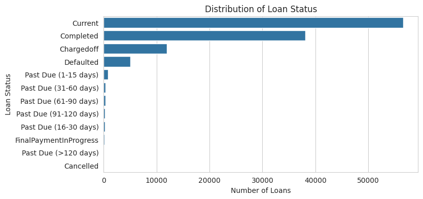

```python
## 📊 Visualization — Count Plot
plt.figure(figsize=(8, 4))
sns.countplot(
    data=df_loans,
    y='LoanStatus',
    order=df_loans['LoanStatus'].value_counts().index
)
plt.title('Distribution of Loan Status')
plt.xlabel('Number of Loans')
plt.ylabel('Loan Status')
plt.show()
```

## Univariate Exploration

> In this section, individual variables are explored to understand their distributions and identify potential outliers or unusual patterns. This step helps establish a solid foundation for analyzing relationships between variables in later sections.

> The exploration follows a logical progression:
> 1. Loan outcome distribution
> 2. Key risk and pricing variables
> 3. Borrower financial characteristics

## Observations

> Most loans are either **Current** or **Completed**, indicating that the majority of loans are performing as expected. However, a noticeable number of loans fall into **Chargedoff** or **Defaulted** categories, highlighting the importance of understanding borrower risk factors and loan pricing.

## 🔹 Variable 2: Borrower APR (BorrowerAPR)

> ❓ Question

> How is the Borrower APR distributed across loans?

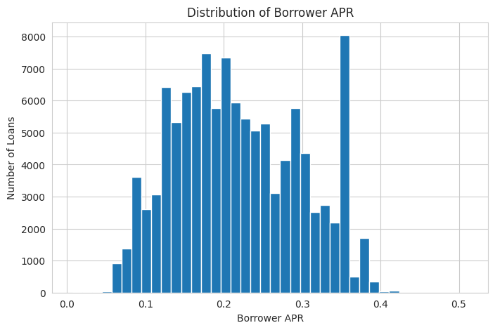

```python
## Visualization — Histogram
plt.figure(figsize=(8, 5))
plt.hist(df_loans['BorrowerAPR'].dropna(), bins=40)
plt.title('Distribution of Borrower APR')
plt.xlabel('Borrower APR')
plt.ylabel('Number of Loans')
plt.show()
```

## 🔹 Variable 3: Prosper Score (ProsperScore)

> ❓ Question

> How are Prosper Scores distributed among borrowers?

[figure not shown]

```python
## Visualization — Count Plot
plt.figure(figsize=(7, 4))
sns.countplot(
    data=df_loans,
    x='ProsperScore',
    order=sorted(df_loans['ProsperScore'].dropna().unique())
)
plt.title('Distribution of Prosper Scores')
plt.xlabel('Prosper Score')
plt.ylabel('Number of Loans')
plt.show()
```

## Observations

> Prosper Scores are distributed across the full range, with a higher concentration in the mid-to-upper score values. This indicates that while higher-risk borrowers exist, a large proportion of loans are issued to borrowers with moderate to good credit profiles. ``

## 🔹 Variable 4: Debt-to-Income Ratio (DebtToIncomeRatio)

> ❓ Question What does the distribution of borrower debt-to-income ratios look like?

```python
# Convert DebtToIncomeRatio to numeric (coerce errors to NaN)
df_loans['DebtToIncomeRatio'] = pd.to_numeric(df_loans['DebtToIncomeRatio'], errors='coerce')

# Quick check
df_loans['DebtToIncomeRatio'].dtype, df_loans['DebtToIncomeRatio'].isna().mean()
```

```
(dtype('float64'), 0.08221209966911538)
```

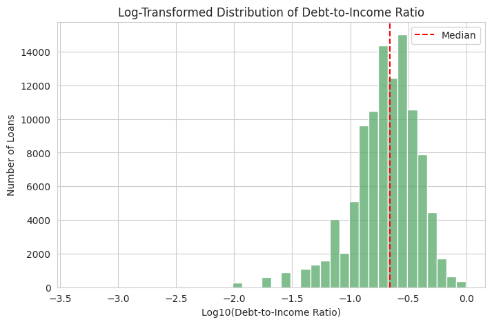

```python
dti = df_loans['DebtToIncomeRatio'].dropna()

# Keep only positive values (log requires > 0)
dti = dti[dti > 0]

plt.figure(figsize=(8, 5))

sns.histplot(
    x=np.log10(dti),
    bins=40,
    color='#55A868'
)

plt.axvline(np.log10(dti.median()), color='red', linestyle='--', label='Median')

plt.title('Log-Transformed Distribution of Debt-to-Income Ratio')
plt.xlabel('Log10(Debt-to-Income Ratio)')
plt.ylabel('Number of Loans')
plt.legend()
plt.show()
```

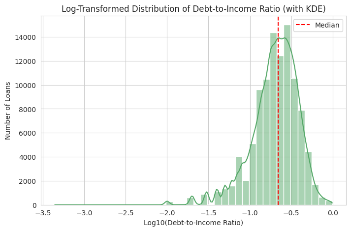

```python
plt.figure(figsize=(8, 5))

sns.histplot(
    x=np.log10(dti),
    bins=40,
    kde=True,
    color='#55A868'
)

plt.axvline(np.log10(dti.median()), color='red', linestyle='--', label='Median')

plt.title('Log-Transformed Distribution of Debt-to-Income Ratio (with KDE)')
plt.xlabel('Log10(Debt-to-Income Ratio)')
plt.ylabel('Number of Loans')
plt.legend()
plt.show()
```

## Observations

> The debt-to-income ratio distribution is right-skewed, with most borrowers concentrated at relatively low values. A log transformation was applied to reduce skewness and make the distribution easier to interpret. After transformation, the central tendency becomes clearer while still highlighting the presence of higher-debt borrowers.

```python
num_cols = ['BorrowerAPR', 'BorrowerRate', 'LoanOriginalAmount', 'ProsperScore']
for c in num_cols:
    if c in df_loans.columns:
        df_loans[c] = pd.to_numeric(df_loans[c], errors='coerce')
```

### Discuss the distribution(s) of your variable(s) of interest. Were there any unusual points? Did you need to perform any transformations?

> The main features of interest in this dataset are related to **loan outcomes and risk/cost of borrowing**, particularly **LoanStatus**, **BorrowerAPR / BorrowerRate**, and Prosper’s risk measures such as **ProsperScore** and **ProsperRating (Alpha)**.

> **LoanStatus** (loan outcome) is a categorical variable with multiple categories (e.g., Current, Completed, Chargedoff, Defaulted, PastDue). In the univariate exploration, the distribution shows that a large share of loans fall into “Current” and “Completed”, while a smaller but important portion are in negative outcome categories (e.g., “Chargedoff” or “Defaulted”). This imbalance is expected in loan performance data and motivates focusing on how borrower risk variables relate to these outcomes.

> Regarding unusual points, the most notable issues were related to **data formatting and extreme values**. Some numeric-looking fields (e.g., **DebtToIncomeRatio**) were loaded as strings due to non-standard formatting in the raw CSV and required conversion to numeric values using `pd.to_numeric(..., errors='coerce')`. In addition, variables with long right tails (like APR/rates or DTI) can be difficult to interpret on the original scale; therefore, **range restrictions** (for visualization clarity) and in some cases a **log transformation** were used to reduce skewness and better highlight the central distribution. These transformations were applied to improve interpretability rather than to remove information from the dataset.

### Of the features you investigated, were there any unusual distributions? Did you perform any operations on the data to tidy, adjust, or change the form of the data? If so, why did you do this?

> Yes, several features investigated during the univariate exploration displayed **unusual distributions or data quality issues** that required additional attention. One of the most notable cases was **Debt-to-Income Ratio (`DebtToIncomeRatio`)**, which exhibited a strongly right-skewed distribution and contained extreme values. These extreme values made it difficult to interpret the distribution on the original scale.

> Categorical variables such as **LoanStatus** and **ProsperScore** did not display unusual distributions in a technical sense, but the strong imbalance across categories (e.g., many loans being “Current” or “Completed”) was noted. This imbalance is expected in loan performance data and was retained, as it reflects real-world outcomes rather than data quality problems.

> Overall, the adjustments made during univariate exploration were **lightweight and exploratory**, focused on improving interpretability rather than altering the underlying data. These steps prepared the dataset for clearer bivariate and multivariate analysis without compromising the integrity of the original information.

## Bivariate Exploration

> In this section, relationships between pairs of variables are explored to understand how borrower risk characteristics and financial features relate to loan outcomes and pricing. The analysis builds directly on insights from the univariate exploration.

## Scatter plot

> ❓ Question,

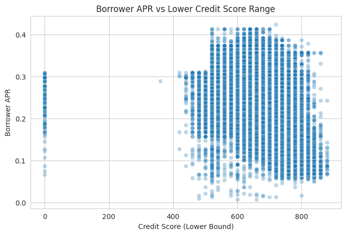

```python
# Ensure numeric
df_loans['CreditScoreRangeLower'] = pd.to_numeric(
    df_loans['CreditScoreRangeLower'], errors='coerce'
)

scatter_df = df_loans[['CreditScoreRangeLower', 'BorrowerAPR']].dropna()

plt.figure(figsize=(8, 5))
sns.scatterplot(
    data=scatter_df,
    x='CreditScoreRangeLower',
    y='BorrowerAPR',
    alpha=0.3
)

plt.title('Borrower APR vs Lower Credit Score Range')
plt.xlabel('Credit Score (Lower Bound)')
plt.ylabel('Borrower APR')
plt.show()
```

## Observations

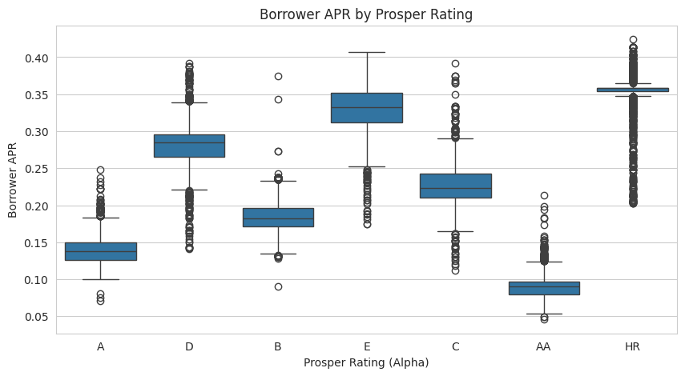

```python
plt.figure(figsize=(10, 5))

sns.boxplot(
    data=df_loans,
    x='ProsperRating (Alpha)',
    y='BorrowerAPR'
)

plt.title('Borrower APR by Prosper Rating')
plt.xlabel('Prosper Rating (Alpha)')
plt.ylabel('Borrower APR')
plt.show()
```

## Observations

### Discussion of Bivariate Relationships

> Several meaningful relationships were observed during the bivariate exploration, particularly involving the main features of interest related to **loan outcomes and borrowing costs**.

> One of the clearest relationships appears between **borrower credit risk measures** and **Borrower APR**. Using credit score ranges as a proxy for borrower risk, loans issued to borrowers with lower credit scores are associated with higher APR values. This inverse relationship indicates that borrowers perceived as higher risk face higher borrowing costs, which aligns with standard credit pricing practices.

## Multivariate Exploration

> Prerequisite: Execute this cell once before the multivariate plots (converts to numeric and filters the basics).

```python
# 0) Convert to numeric (avoids issues with string-type columns)
to_num = ['BorrowerAPR', 'BorrowerRate', 'LoanOriginalAmount',
          'DebtToIncomeRatio', 'CreditScoreRangeLower', 'CreditScoreRangeUpper']

for c in to_num:
    if c in df_loans.columns:
        df_loans[c] = pd.to_numeric(df_loans[c], errors='coerce')

# 1) Base subset (avoids NaN and impossible values)
mv_df = df_loans[['LoanStatus', 'BorrowerAPR', 'CreditScoreRangeLower',
                  'LoanOriginalAmount', 'Term', 'IncomeRange', 'DebtToIncomeRatio']].copy()

mv_df = mv_df.dropna(subset=['LoanStatus', 'BorrowerAPR', 'CreditScoreRangeLower', 'Term'])

# 2)Limit APR to a reasonable range (only for visualization; does not "delete" data from the original dataset)
mv_df = mv_df[(mv_df['BorrowerAPR'] >= 0) & (mv_df['BorrowerAPR'] <= 0.6)]
```

## Faceted plot

> Facet: relationship between "risk (score)" vs "APR" separated by loan status

> ❓ Question

> Does the relationship between risk (credit score) and APR change depending on the loan status (LoanStatus)?

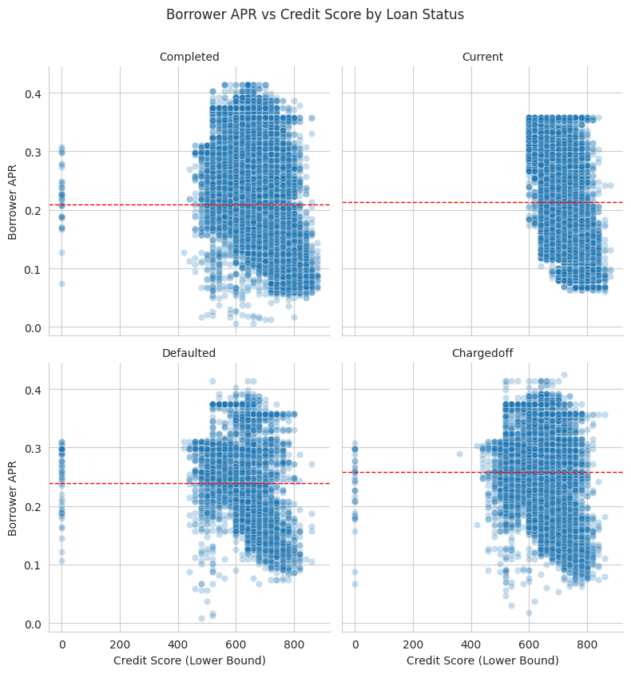

```python
## Visualización (FacetGrid)
top_status = mv_df['LoanStatus'].value_counts().head(4).index
facet_df = mv_df[mv_df['LoanStatus'].isin(top_status)]

g = sns.FacetGrid(
    facet_df,
    col='LoanStatus',
    col_wrap=2,
    height=4,
    sharex=True,
    sharey=True
)

g.map_dataframe(
    sns.scatterplot,
    x='CreditScoreRangeLower',
    y='BorrowerAPR',
    alpha=0.25
)

# Add mean APR line per panel (relevant annotation)
def add_mean_line(data, **kws):
    mean_apr = data['BorrowerAPR'].mean()
    plt.axhline(mean_apr, color='red', linestyle='--', linewidth=1)

g.map_dataframe(add_mean_line)

g.set_axis_labels('Credit Score (Lower Bound)', 'Borrower APR')
g.set_titles('{col_name}')
g.fig.suptitle('Borrower APR vs Credit Score by Loan Status', y=1.05)

plt.show()
```

## Observations

> Across loan status categories, higher credit scores tend to be associated with lower APRs. The mean APR (red dashed line) differs by loan status, suggesting that loan outcomes may be linked to systematic differences in borrower risk and pricing.

## Scatter plot with multiple encodings

> Same relationship, but encoding 3–4 variables simultaneously

> ❓ Question

> How are APR and credit score related when distinguishing by loan status and loan amount size?

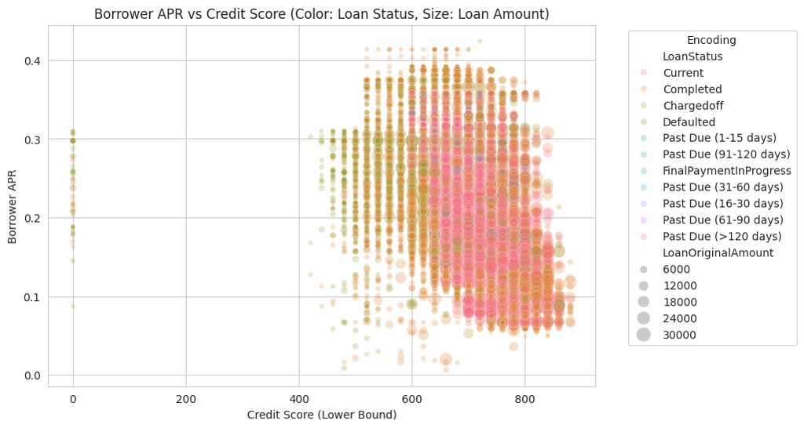

```python
## Visualization (color + size)
plot_df = mv_df.dropna(subset=['LoanOriginalAmount']).copy()

# (opcional) muestreo para rendimiento y legibilidad
if plot_df.shape[0] > 50000:
    plot_df = plot_df.sample(50000, random_state=42)

plt.figure(figsize=(9, 6))

sns.scatterplot(
    data=plot_df,
    x='CreditScoreRangeLower',
    y='BorrowerAPR',
    hue='LoanStatus',
    size='LoanOriginalAmount',
    sizes=(20, 200),
    alpha=0.25
)

plt.title('Borrower APR vs Credit Score (Color: Loan Status, Size: Loan Amount)')
plt.xlabel('Credit Score (Lower Bound)')
plt.ylabel('Borrower APR')
plt.legend(title='Encoding', bbox_to_anchor=(1.05, 1), loc='upper left')
plt.show()
```

## Observations

> The multi-encoding scatter plot reinforces the negative relationship between credit score and APR. Coloring by loan status highlights that some statuses tend to cluster at higher APR ranges. Encoding loan amount by point size suggests that loan size varies across the risk-pricing space, although the relationship appears less direct than credit score vs APR.

> ❓ Question

> How does the mean APR change according to LoanStatus and Term (loan term)?

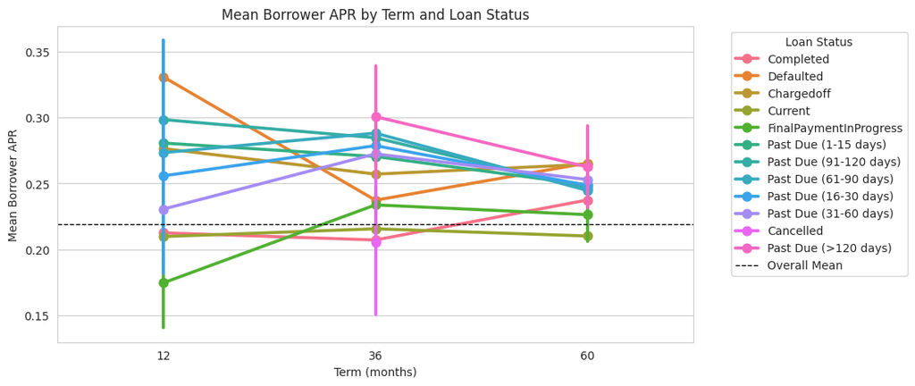

```python
## Visualization (grouped bars with mean + CI)

# We use pointplot for means + confidence interval (more informative)

plt.figure(figsize=(10, 5))

sns.pointplot(
    data=mv_df,
    x='Term',
    y='BorrowerAPR',
    hue='LoanStatus',
    errorbar=('ci', 95)
)

# Annotation: global mean APR line

global_mean = mv_df['BorrowerAPR'].mean()
plt.axhline(global_mean, color='black', linestyle='--', linewidth=1, label='Overall Mean')

plt.title('Mean Borrower APR by Term and Loan Status')
plt.xlabel('Term (months)')
plt.ylabel('Mean Borrower APR')
plt.legend(title='Loan Status', bbox_to_anchor=(1.05, 1), loc='upper left')
plt.show()
```

## Observations

> Average APR varies by both term and loan status. The overall mean line helps contextualize which groups are above or below typical pricing. This suggests that loan configuration (term length) interacts with outcome categories in loan pricing patterns.

## Conclusions

> This exploratory analysis examined the Prosper Loan dataset with the goal of understanding how **borrower risk, loan characteristics, and pricing** relate to **loan outcomes**. By progressing systematically through univariate, bivariate, and multivariate exploration, several key findings and methodological insights emerged.